# Data Analytics: Assignment 2 Group 6

29.03.2023

### Load the caret package for data partitioning

```r
library("caret")
```

### Task 1: Load the data

Load the churn dataset from a [URL](https://statmath.wu.ac.at/~malsiner/datasets/churn.csv) and convert the churn variable to binary

```r
churndat <- read.csv(url("https://statmath.wu.ac.at/~malsiner/datasets/churn.csv"))
churndat$churn <- ifelse(churndat$churn == "Yes", 1, 0)
```

Convert the internationalplan and voicemailplan variables to binary

```r
churndat$internationalplan <- ifelse(churndat$internationalplan == "yes", 1, 0)
churndat$voicemailplan <- ifelse(churndat$voicemailplan == "yes", 1, 0)
```

```r
#structure of the data
str(churndat)
```

```
## 'data.frame':    5000 obs. of  18 variables:
##  $ churn                     : num  0 0 0 0 0 0 0 0 0 0 ...
##  $ accountlength             : int  128 107 137 84 75 118 121 147 117 141 ...
##  $ internationalplan         : num  0 0 0 1 1 1 0 1 0 1 ...
##  $ voicemailplan             : num  1 1 0 0 0 0 1 0 0 1 ...
##  $ numbervmailmessages       : int  25 26 0 0 0 0 24 0 0 37 ...
##  $ totaldayminutes           : num  265 162 243 299 167 ...
##  $ totaldaycalls             : int  110 123 114 71 113 98 88 79 97 84 ...
##  $ totaldaycharge            : num  45.1 27.5 41.4 50.9 28.3 ...
##  $ totaleveminutes           : num  197.4 195.5 121.2 61.9 148.3 ...
##  $ totalevecalls             : int  99 103 110 88 122 101 108 94 80 111 ...
##  $ totalevecharge            : num  16.78 16.62 10.3 5.26 12.61 ...
##  $ totalnightminutes         : num  245 254 163 197 187 ...
##  $ totalnightcalls           : int  91 103 104 89 121 118 118 96 90 97 ...
##  $ totalnightcharge          : num  11.01 11.45 7.32 8.86 8.41 ...
##  $ totalintlminutes          : num  10 13.7 12.2 6.6 10.1 6.3 7.5 7.1 8.7 11.2 ...
##  $ totalintlcalls            : int  3 3 5 7 3 6 7 6 4 5 ...
##  $ totalintlcharge           : num  2.7 3.7 3.29 1.78 2.73 1.7 2.03 1.92 2.35 3.02 ...
##  $ numbercustomerservicecalls: int  1 1 0 2 3 0 3 0 1 0 ...
```

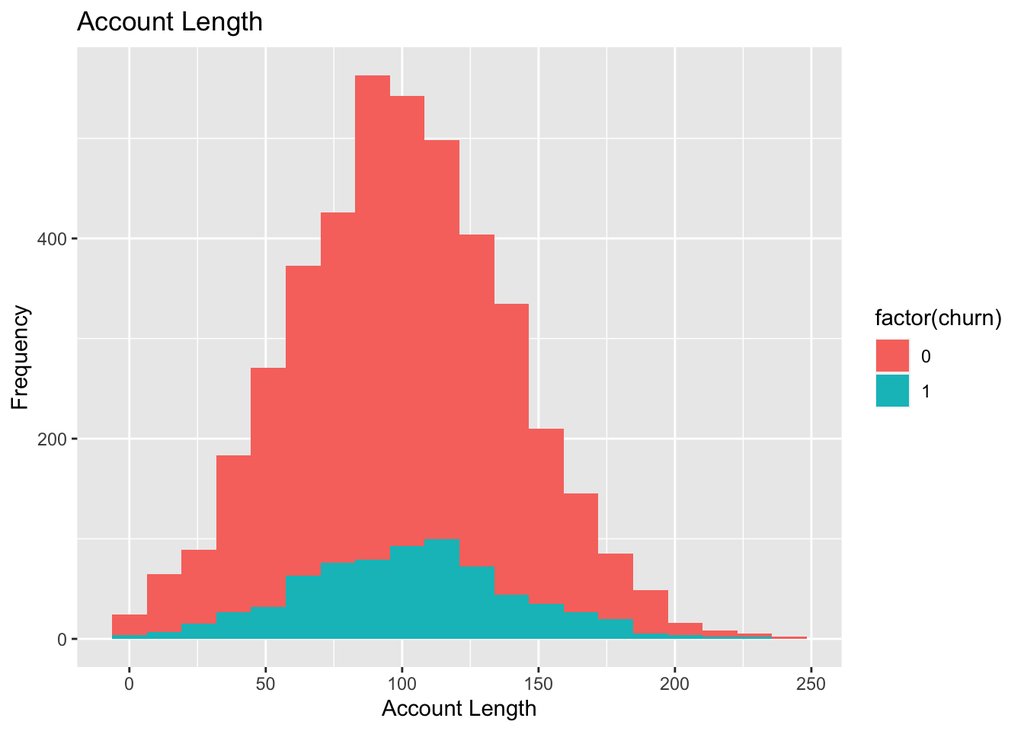

```r
#Generate appropriate graphs for all variables differentiated into churn vs. no churn.
#accountlength
ggplot(churndat, aes(x = accountlength, fill = factor(churn))) + geom_histogram(bins = 20, position = "identity") + labs(title = "Account Length", x = "Account Length", y = "Frequency")
```

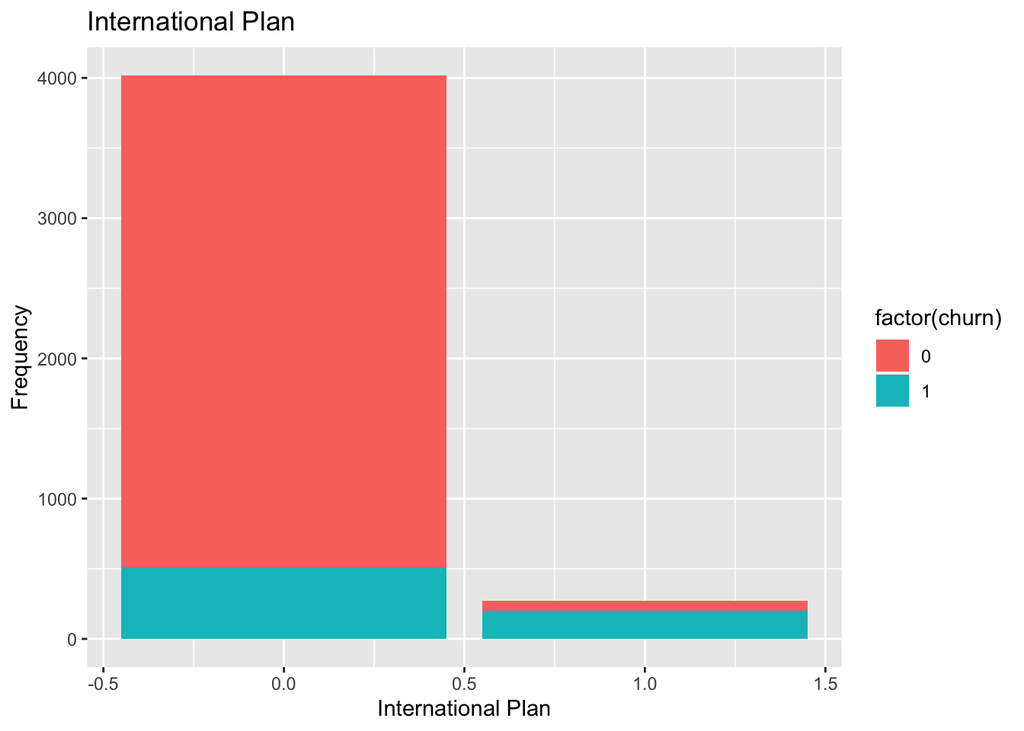

```r
#internationalplan
ggplot(churndat, aes(x = internationalplan, fill = factor(churn))) + geom_bar(position = "identity") + labs(title = "International Plan", x = "International Plan", y = "Frequency")
```

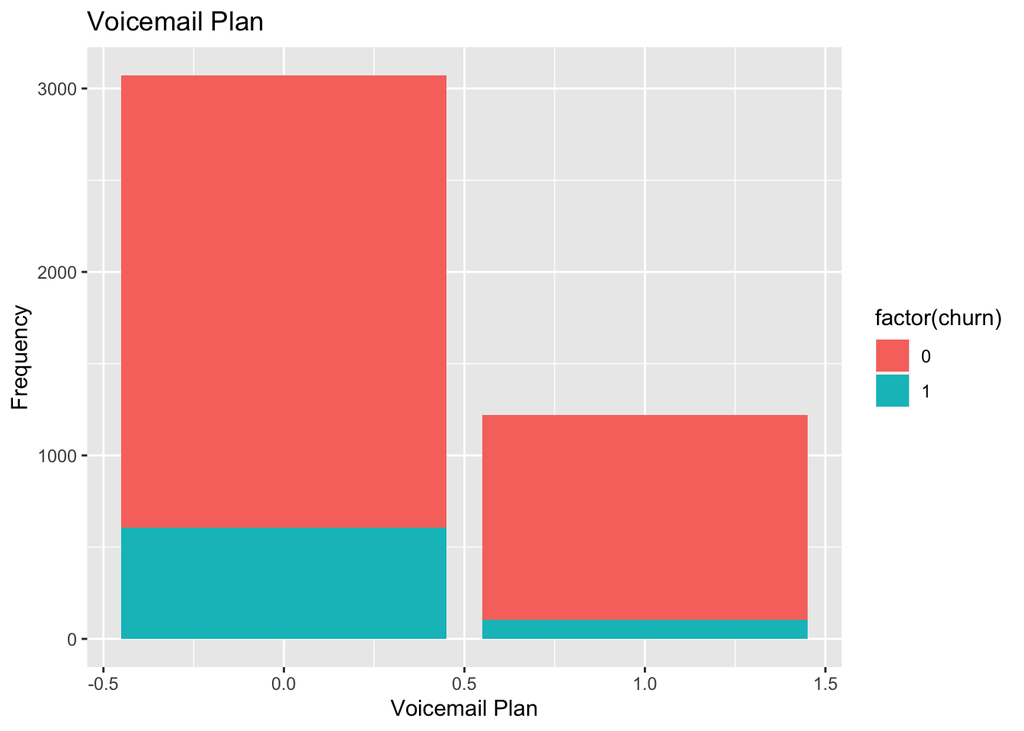

```r
#voicemailplan
ggplot(churndat, aes(x = voicemailplan, fill = factor(churn))) + geom_bar(position = "identity") + labs(title = "Voicemail Plan", x = "Voicemail Plan", y = "Frequency")
```

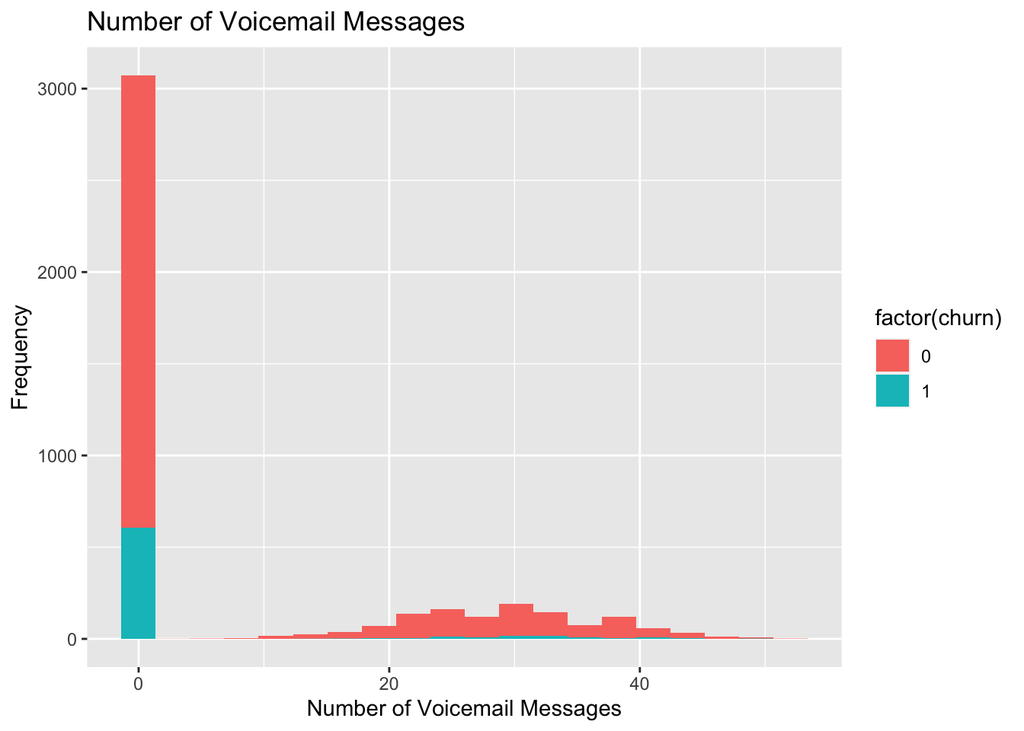

```r
#numbervmailmessages
ggplot(churndat, aes(x = numbervmailmessages, fill = factor(churn))) + geom_histogram(bins = 20, position = "identity") + labs(title = "Number of Voicemail Messages", x = "Number of Voicemail Messages", y = "Frequency")
```

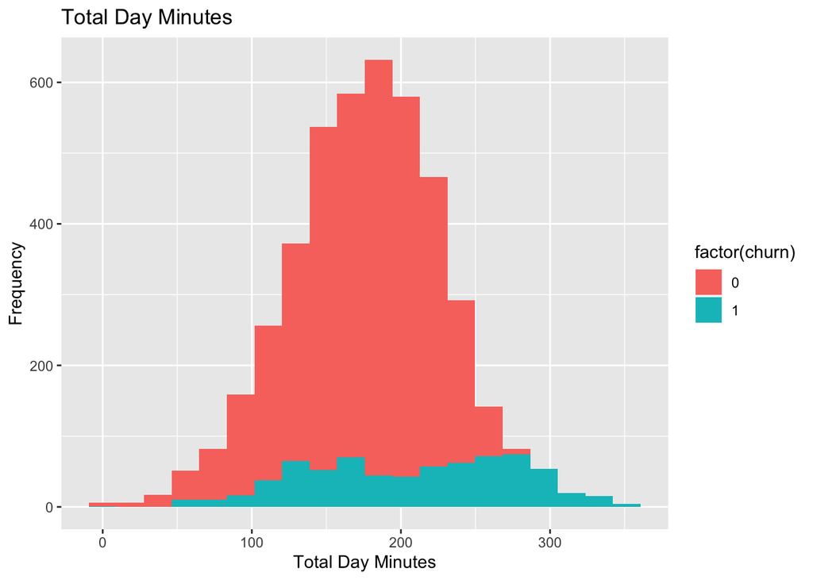

```r
#totaldayminutes
ggplot(churndat, aes(x = totaldayminutes, fill = factor(churn))) + geom_histogram(bins = 20, position = "identity") + labs(title = "Total Day Minutes", x = "Total Day Minutes", y = "Frequency")
```

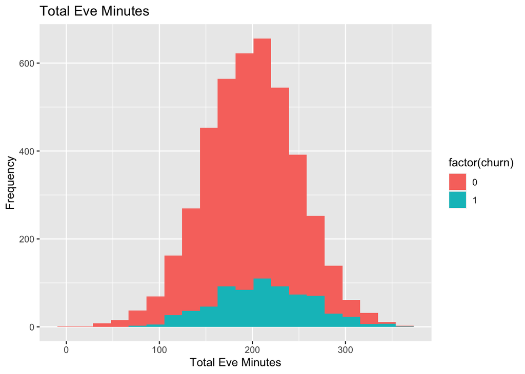

```r
#totaleveminutes
ggplot(churndat, aes(x = totaleveminutes, fill = factor(churn))) + geom_histogram(bins = 20, position = "identity") + labs(title = "Total Eve Minutes", x = "Total Eve Minutes", y = "Frequency")
```

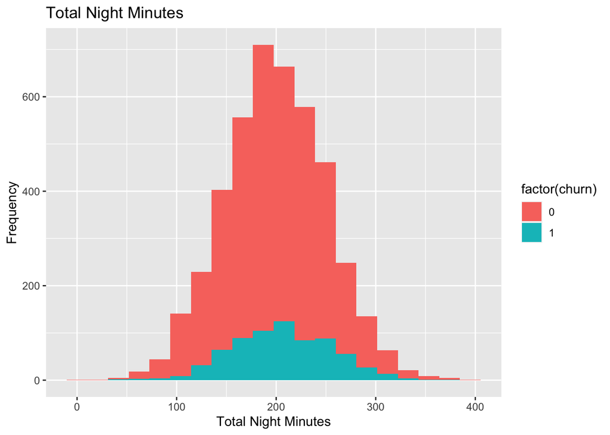

```r
#totalnightminutes
ggplot(churndat, aes(x = totalnightminutes, fill = factor(churn))) + geom_histogram(bins = 20, position = "identity") + labs(title = "Total Night Minutes", x = "Total Night Minutes", y = "Frequency")
```

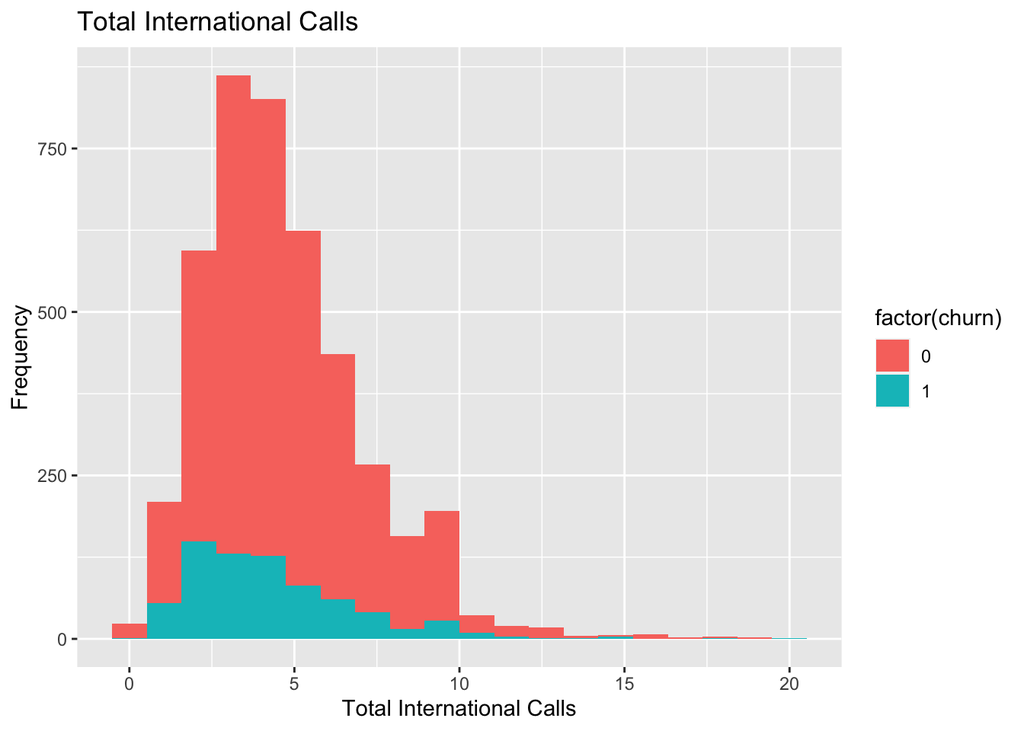

```r
#totalintlcalls
ggplot(churndat, aes(x = totalintlcalls, fill = factor(churn))) + geom_histogram(bins = 20, position = "identity") + labs(title = "Total International Calls", x = "Total International Calls", y = "Frequency")
```

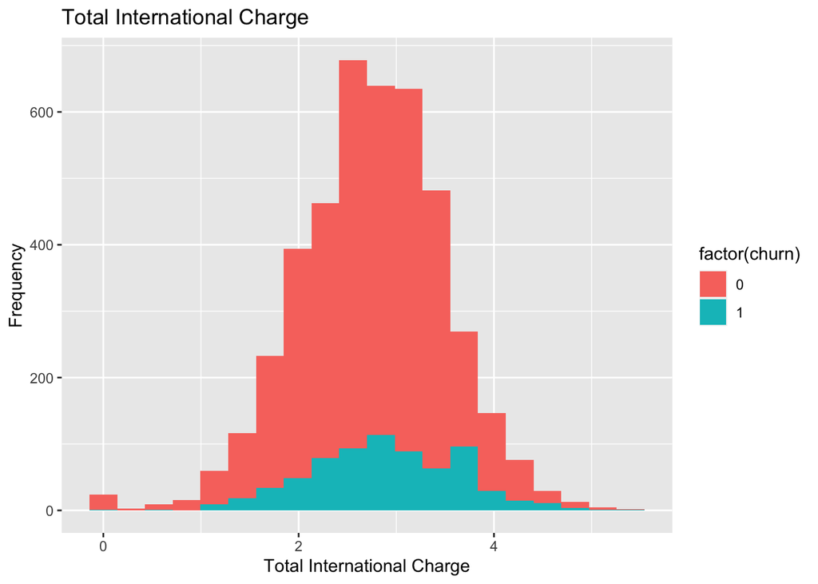

```r
#totalintlcharge
ggplot(churndat, aes(x = totalintlcharge, fill = factor(churn))) + geom_histogram(bins = 20, position = "identity") + labs(title = "Total International Charge", x = "Total International Charge", y = "Frequency")
```

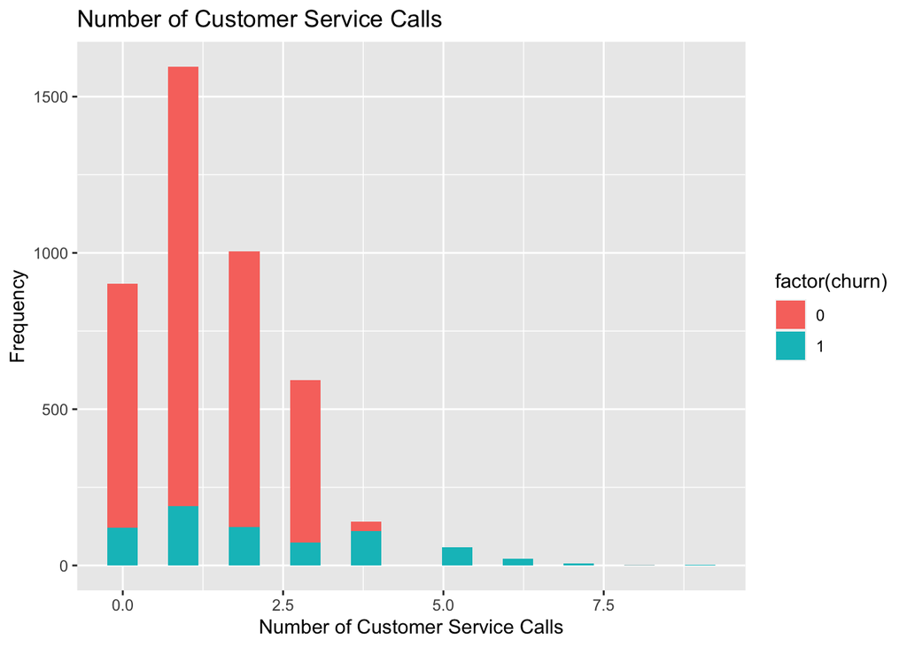

```r
#numbercustomerservicecalls
ggplot(churndat, aes(x = numbercustomerservicecalls, fill = factor(churn))) + geom_histogram(bins = 20, position = "identity") + labs(title = "Number of Customer Service Calls", x = "Number of Customer Service Calls", y = "Frequency")
```

There seems to be a relationship with churn and international plan. If the user has no International plan the churn rate is way lower compared to users with an international plan It is the opposite with the Voicemail plan, if the user has one the churn rate is lower. Also with a rising number of customer service calls the churn rate seems to go up. For all the other variables it is difficult to tell and there seems to be no real correlation at first sight.

### Task 2: Splitting the data to training set and test set

Split the data into training and testing sets, with 80% for training and 20% for testing

```r
set.seed(123) # for reproducibility
train_index <- createDataPartition(churndat$churn, p = 0.8, list = FALSE)
train <- churndat[train_index, ]
test <- churndat[-train_index, ]
```

### Task 3: Full logistic regression model

Fit a logistic regression model to the training data using all variables as predictors

```r
mlm <- glm(churn ~ ., data = train, family = binomial())
```

Print a summary of the logistic regression model

```r
summary(mlm)
```

```
##
## Call:
## glm(formula = churn ~ ., family = binomial(), data = train)
##
## Deviance Residuals:
##     Min       1Q   Median       3Q      Max
## -2.1536  -0.5059  -0.3364  -0.1890   3.0516
##
## Coefficients:
##                              Estimate Std. Error z value Pr(>|z|)
## (Intercept)                -8.467e+00  6.621e-01 -12.788  < 2e-16 ***
## accountlength               1.979e-03  1.281e-03   1.545  0.12246
## internationalplan           2.086e+00  1.362e-01  15.321  < 2e-16 ***
## voicemailplan              -2.292e+00  5.219e-01  -4.391 1.13e-05 ***
## numbervmailmessages         3.978e-02  1.604e-02   2.480  0.01315 *
## totaldayminutes             5.108e+00  3.003e+00   1.701  0.08897 .
## totaldaycalls               2.571e-03  2.580e-03   0.996  0.31906
## totaldaycharge             -2.996e+01  1.767e+01  -1.696  0.08984 .
## totaleveminutes             5.469e-01  1.505e+00   0.363  0.71631
## totalevecalls              -3.736e-04  2.596e-03  -0.144  0.88556
## totalevecharge             -6.356e+00  1.771e+01  -0.359  0.71961
## totalnightminutes           2.327e-01  7.989e-01   0.291  0.77079
## totalnightcalls            -2.483e-03  2.564e-03  -0.969  0.33276
## totalnightcharge           -5.087e+00  1.775e+01  -0.287  0.77446
## totalintlminutes            1.160e+00  4.861e+00   0.239  0.81133
## totalintlcalls             -7.363e-02  2.266e-02  -3.249  0.00116 **
## totalintlcharge            -3.941e+00  1.801e+01  -0.219  0.82674
## numbercustomerservicecalls  5.061e-01  3.626e-02  13.960  < 2e-16 ***
## ---
## Signif. codes:  0 '***' 0.001 '**' 0.01 '*' 0.05 '.' 0.1 ' ' 1
##
## (Dispersion parameter for binomial family taken to be 1)
##
##     Null deviance: 3293.7  on 3999  degrees of freedom
## Residual deviance: 2551.8  on 3982  degrees of freedom
## AIC: 2587.8
##
## Number of Fisher Scoring iterations: 6
```

Print a summary of the logistic regression model

```r
summary(mlm)
```

```
##
## Call:
## glm(formula = churn ~ ., family = binomial(), data = train)
##
## Deviance Residuals:
##     Min       1Q   Median       3Q      Max
## -2.1536  -0.5059  -0.3364  -0.1890   3.0516
##
## Coefficients:
##                              Estimate Std. Error z value Pr(>|z|)
## (Intercept)                -8.467e+00  6.621e-01 -12.788  < 2e-16 ***
## accountlength               1.979e-03  1.281e-03   1.545  0.12246
## internationalplan           2.086e+00  1.362e-01  15.321  < 2e-16 ***
## voicemailplan              -2.292e+00  5.219e-01  -4.391 1.13e-05 ***
## numbervmailmessages         3.978e-02  1.604e-02   2.480  0.01315 *
## totaldayminutes             5.108e+00  3.003e+00   1.701  0.08897 .
## totaldaycalls               2.571e-03  2.580e-03   0.996  0.31906
## totaldaycharge             -2.996e+01  1.767e+01  -1.696  0.08984 .
## totaleveminutes             5.469e-01  1.505e+00   0.363  0.71631
## totalevecalls              -3.736e-04  2.596e-03  -0.144  0.88556
## totalevecharge             -6.356e+00  1.771e+01  -0.359  0.71961
## totalnightminutes           2.327e-01  7.989e-01   0.291  0.77079
## totalnightcalls            -2.483e-03  2.564e-03  -0.969  0.33276
## totalnightcharge           -5.087e+00  1.775e+01  -0.287  0.77446
## totalintlminutes            1.160e+00  4.861e+00   0.239  0.81133
## totalintlcalls             -7.363e-02  2.266e-02  -3.249  0.00116 **
## totalintlcharge            -3.941e+00  1.801e+01  -0.219  0.82674
## numbercustomerservicecalls  5.061e-01  3.626e-02  13.960  < 2e-16 ***
## ---
## Signif. codes:  0 '***' 0.001 '**' 0.01 '*' 0.05 '.' 0.1 ' ' 1
##
## (Dispersion parameter for binomial family taken to be 1)
##
##     Null deviance: 3293.7  on 3999  degrees of freedom
## Residual deviance: 2551.8  on 3982  degrees of freedom
## AIC: 2587.8
##
## Number of Fisher Scoring iterations: 6
```

The significant variables in this model are: **internationalplan**, **voicemailplan**, **numbervmailmessages**, **totalintlcalls** and **numbercustomerservicecalls**.

### Task 4: Logistic model stepwise analysis

Perform stepwise variable selection on the logistic regression model using both forward and backward selection The ‘trace’ argument controls the amount of output produced during the stepwise procedure

```r
mlm_step <- step(mlm, direction = "both", trace = FALSE)
```

Print a summary of the stepwise logistic regression model

```r
summary(mlm_step)
```

```
##
## Call:
## glm(formula = churn ~ accountlength + internationalplan + voicemailplan +
##     numbervmailmessages + totaldayminutes + totaldaycharge +
##     totaleveminutes + totalnightminutes + totalintlminutes +
##     totalintlcalls + numbercustomerservicecalls, family = binomial(),
##     data = train)
##
## Deviance Residuals:
##     Min       1Q   Median       3Q      Max
## -2.1261  -0.5092  -0.3364  -0.1888   3.0494
##
## Coefficients:
##                              Estimate Std. Error z value Pr(>|z|)
## (Intercept)                -8.491e+00  4.916e-01 -17.272  < 2e-16 ***
## accountlength               2.024e-03  1.282e-03   1.579 0.114312
## internationalplan           2.085e+00  1.361e-01  15.327  < 2e-16 ***
## voicemailplan              -2.297e+00  5.207e-01  -4.411 1.03e-05 ***
## numbervmailmessages         3.990e-02  1.600e-02   2.493 0.012659 *
## totaldayminutes             5.139e+00  3.002e+00   1.712 0.086936 .
## totaldaycharge             -3.015e+01  1.766e+01  -1.707 0.087794 .
## totaleveminutes             6.628e-03  1.051e-03   6.307 2.85e-10 ***
## totalnightminutes           3.784e-03  9.996e-04   3.786 0.000153 ***
## totalintlminutes            9.668e-02  1.887e-02   5.123 3.01e-07 ***
## totalintlcalls             -7.476e-02  2.264e-02  -3.302 0.000960 ***
## numbercustomerservicecalls  5.068e-01  3.622e-02  13.990  < 2e-16 ***
## ---
## Signif. codes:  0 '***' 0.001 '**' 0.01 '*' 0.05 '.' 0.1 ' ' 1
##
## (Dispersion parameter for binomial family taken to be 1)
##
##     Null deviance: 3293.7  on 3999  degrees of freedom
## Residual deviance: 2554.0  on 3988  degrees of freedom
## AIC: 2578
##
## Number of Fisher Scoring iterations: 6
```

Calculate the predicted probabilities and predicted classes of the testing data using the stepwise logistic regression model

```r
test$prob_churn_step <- predict(mlm_step, newdata = test, type = "response")
test$class_churn_step <- ifelse(test$prob_churn_step > 0.5, 1, 0)
```

Calculate the accuracy, sensitivity, and specificity of the stepwise logistic regression model on the testing data

```r
accuracy_step <- sum(test$class_churn_step == test$churn) / nrow(test)
sensitivity_step <- sum(test$class_churn_step[test$churn == 1] == 1) / sum(test$churn == 1)
specificity_step <- sum(test$class_churn_step[test$churn == 0] == 0) / sum(test$churn == 0)
```

Print the accuracy, sensitivity, and specificity of the stepwise logistic regression model on the testing data

```r
cat("Accuracy: ", round(accuracy_step, 4), "\n")
```

```
## Accuracy:  0.877
```

```r
cat("Sensitivity: ", round(sensitivity_step, 4), "\n")
```

```
## Sensitivity:  0.2197
```

```r
cat("Specificity: ", round(specificity_step, 4), "\n")
```

```
## Specificity:  0.977
```

### Task 5: k-NN modell using 5 fold cross-validation

```r
fitControl <- trainControl(method = "cv", number = 5)

logFit <- train(as.factor(churn) ~ scale(accountlength) + internationalplan + voicemailplan + scale(totalintlcharge) + scale(numbervmailmessages) + scale(totaldayminutes) + scale(totaldaycharge) + scale(totalevecalls) + scale(totaleveminutes) + scale(totalnightminutes) + scale(totalintlminutes) +
scale(totalintlcalls) + scale(numbercustomerservicecalls) + scale(totalnightcharge) + scale(totaldaycalls) + scale(totalevecharge) + scale(totalnightcalls),data = train, method= "knn", tuneGrid = data.frame(k = 1:10), trControl = fitControl)

logFit
```

```
## k-Nearest Neighbors
##
## 4000 samples
##   17 predictor
##    2 classes: '0', '1'
##
## No pre-processing
## Resampling: Cross-Validated (5 fold)
## Summary of sample sizes: 3200, 3200, 3200, 3200, 3200
## Resampling results across tuning parameters:
##
##   k   Accuracy  Kappa
##    1  0.85425   0.3296702
##    2  0.85125   0.3169456
##    3  0.88300   0.3651291
##    4  0.88325   0.3615788
##    5  0.88675   0.3519272
##    6  0.88525   0.3405273
##    7  0.88375   0.3130464
##    8  0.88550   0.3283657
##    9  0.88325   0.3010977
##   10  0.88200   0.2893749
##
## Accuracy was used to select the optimal model using the largest value.
## The final value used for the model was k = 5.
```

### Task 6: Naive Bayes model estemated on training sample

```r
library(e1071)
fit_nb = naiveBayes(churn ~ internationalplan + voicemailplan + numbercustomerservicecalls + totalintlcalls + numbervmailmessages, data = train)

fit_nb
```

```
##
## Naive Bayes Classifier for Discrete Predictors
##
## Call:
## naiveBayes.default(x = X, y = Y, laplace = laplace)
##
## A-priori probabilities:
## Y
##       0       1
## 0.85625 0.14375
##
## Conditional probabilities:
##    internationalplan
## Y         [,1]      [,2]
##   0 0.06335766 0.2436407
##   1 0.27826087 0.4485328
##
##    voicemailplan
## Y        [,1]      [,2]
##   0 0.2893431 0.4535237
##   1 0.1530435 0.3603429
##
##    numbercustomerservicecalls
## Y       [,1]     [,2]
##   0 1.455182 1.165029
##   1 2.250435 1.843123
##
##    totalintlcalls
## Y       [,1]     [,2]
##   0 4.446715 2.429167
##   1 4.130435 2.552316
##
##    numbervmailmessages
## Y       [,1]     [,2]
##   0 8.474161 13.95292
##   1 4.827826 11.73101
```

### Task 7: Comparing the different methods

```r
# Predict churn using the k-NN model
library(class)
knn_pred <- knn(train[,c("internationalplan", "voicemailplan", "numbercustomerservicecalls", "totalintlcalls", "numbervmailmessages")], test[,c("internationalplan", "voicemailplan", "numbercustomerservicecalls", "totalintlcalls", "numbervmailmessages")], train$churn, k=5)
knn_cm <- table(test$churn, knn_pred)
knn_accuracy <- sum(diag(knn_cm))/sum(knn_cm)

# Predict churn using the Naive Bayes model
nb_pred <- predict(fit_nb, newdata = test)
nb_cm <- table(test$churn, nb_pred)
nb_accuracy <- sum(diag(nb_cm))/sum(nb_cm)

# Calculate accuracy, sensitivity, and specificity of the stepwise logistic regression model
test$prob_churn_step <- predict(mlm_step, newdata = test, type = "response")
test$class_churn_step <- ifelse(test$prob_churn_step > 0.5, 1, 0)
accuracy_step <- sum(test$class_churn_step == test$churn) / nrow(test)
sensitivity_step <- sum(test$class_churn_step[test$churn == 1] == 1) / sum(test$churn == 1)
specificity_step <- sum(test$class_churn_step[test$churn == 0] == 0) / sum(test$churn == 0)

# Print the evaluation metrics
cat("Stepwise logistic regression model: Accuracy=", round(accuracy_step, 4), " Sensitivity=", round(sensitivity_step, 4), " Specificity=", round(specificity_step, 4), "\n")
```

```
## Stepwise logistic regression model: Accuracy= 0.877  Sensitivity= 0.2197  Specificity= 0.977
```

```r
cat("k-NN model: Accuracy=", round(knn_accuracy, 4), " Sensitivity=", round(knn_cm[2,2]/sum(knn_cm[2,]), 4), " Specificity=", round(knn_cm[1,1]/sum(knn_cm[1,]), 4), "\n")
```

```
## k-NN model: Accuracy= 0.878  Sensitivity= 0.2045  Specificity= 0.9804
```

```r
cat("Naive Bayes model: Accuracy=", round(nb_accuracy, 4), " Sensitivity=", round(nb_cm[2,2]/sum(nb_cm[2,]), 4), " Specificity=", round(nb_cm[1,1]/sum(nb_cm[1,]), 4), "\n")
```

```
## Naive Bayes model: Accuracy= 0.853  Sensitivity= 0.3636  Specificity= 0.9274
```